# Bivariate analyses

Up to now, the domain of univariate analyses has allowed us to explore the properties of **one variable at the time**. Investigating the relationship between **two variables** is the topic of bivariate analyses. One good visual starting point to identify these is to plot **pairwise relationships** of all the variables in our dataset.

Let’s go back to our `df_traces_sub` dataset. We can then plot a pairwise comparison plot using *Seaborn*’s `.pairplot()` function ([doc](https://seaborn.pydata.org/generated/seaborn.pairplot.html); Listing 1). We use the `hue` argument of the `.pairplot()` function to plot each epoch in a different color:

Listing 1: Pairwise comparison plot using Seaborn

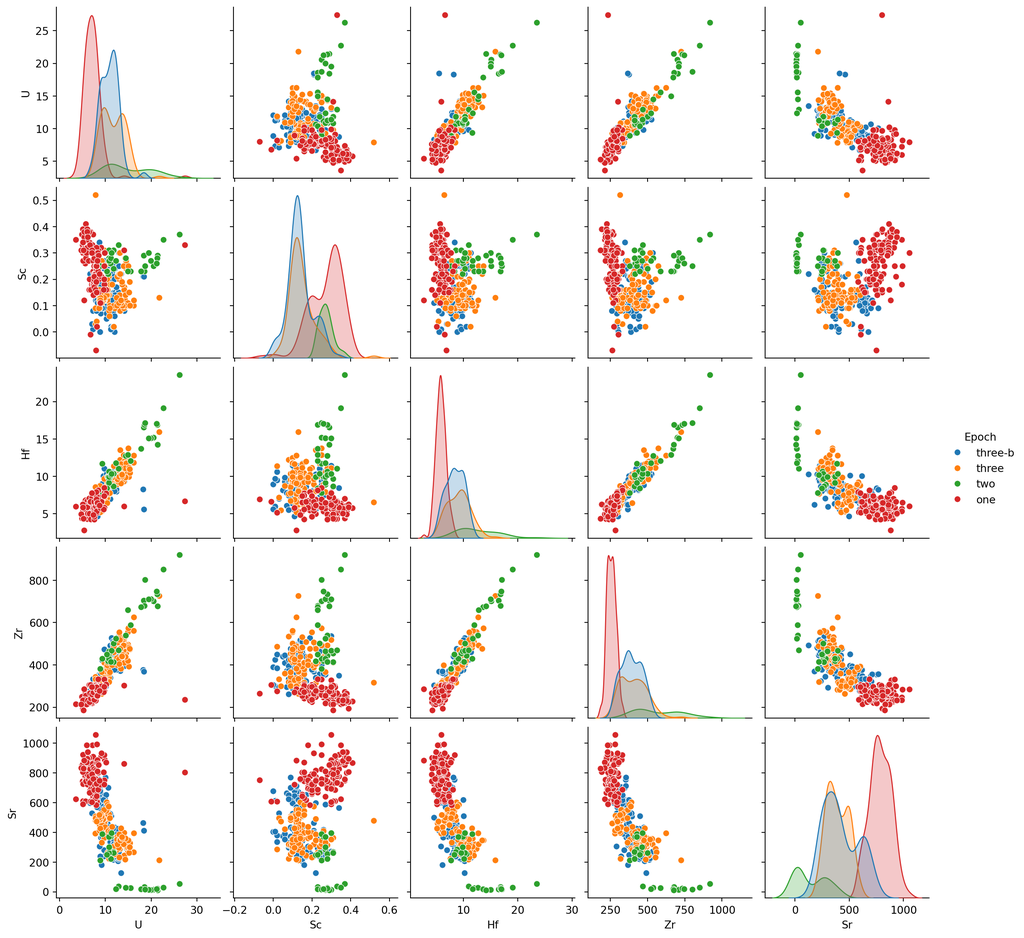

```python
df_traces_sub = df_traces[['Epoch', 'U', 'Sc', 'Hf', 'Zr', 'Sr']]
sns.pairplot(data=df_traces_sub, hue='Epoch')
```

**Your turn!**

For single variables:

Now, thinking about the relationship between **two variables**:

- What variables behave in a similar way?
- What variables don’t?
- Do you see any **clustering** emerge?

## Covariance and correlation

From Listing 1 we can fairly intuitively get that some variables show coupled behaviours (e.g., *Zr* tends to increase whe *Hf* does), whereas the behaviour of other variables suggests much less coupling (e.g., *Sc* and *Hf*).

The first measure used to quantify the joint variability of two random variables $X$ and $Y$ is the theoretical covariance, defined as:
$$\mathrm{Cov}(X,Y) = \mathbb{E}\big[(X - \mathbb{E}[X])(Y - \mathbb{E}[Y])\big],$$

where $\mathbb{E}[X]$ and $\mathbb{E}[Y]$ are the expectations of $X$ and $Y$. The covariance captures the direction and magnitude of the linear relationship between the two variables. Positive values indicate that larger values of $X$ tend to correspond to larger values of $Y$, and negative values indicate the opposite.

In practice, we rarely know the full distribution of $X$ and $Y$, so we compute the sample covariance (Equation 1) as an estimator of the theoretical covariance from a dataset $x_1, \dots, x_n$ and $y_1, \dots, y_n$:

$$\mathrm{Cov}(X,Y)_{\text{emp}}= \frac{1}{n-1}\sum_{i=1}^n (x_i - \bar{x})(y_i - \bar{y}),
\tag{1}$$

where $\bar{x}$ and $\bar{y}$ are the sample means. In *Pandas*, this can be computed using the `.cov()` function (Listing 2).

The covariance depends on the magnitudes of the variables, so it does not directly reflect the strength of the relationship. To address this, the correlation coefficient provides a normalized version of the covariance, ranging from $−1$ to $1$, which indicates both the direction and the strength of the linear relationship. The correlation coefficient is given by:

$$r(X,Y)= \frac{\mathrm{Cov}(X,Y)}{\sigma_X \sigma_Y}$$

The sample correlation (Equation 2) is defined as
$$r(X,Y)_{\text{emp}} = \frac{\mathrm{Cov}(X,Y)_{\text{emp}}}{s_X s_Y} = \frac{\sum_{i=1}^n (x_i - \bar x)(y_i - \bar y)}{\sqrt{\sum_{i=1}^n (x_i - \bar x)^2}\;\sqrt{\sum_{i=1}^n (y_i - \bar y)^2}},
\tag{2}$$
and can be computed in *Pandas* using the `.corr()` function (Listing 2):

where $s_X$ and $s_Y$ are the sample standard deviations of $X$ and $Y$.

- $r(X,Y)>0$ indicates a **positive relationship** between $X$ and $Y$ (→ $Y$ increases when $X$ does);
- $r(X,Y)<0$ indicates a **negative relationship** between $X$ and $Y$ (→ $Y$ decreases when $X$ increases);
- $r(X,Y) =0$ indicates **independence** between $X$ and $Y$.

Listing 2: Computing the sample covariance and correlation coefficient in Pandas. Both the .cov() and the .corr() functions require numerical data, so we first need to remove the Epoch column. Note that the range of values returned by .corr() ranges from -1 to 1.

```python
# We remove the "Epoch" column using the function drop() as it does not contain numerical values
df_traces_sub = df_traces_sub.drop(columns='Epoch')

# Compute the covariance
df_traces_sub.cov()
print(f"The covariance for U ranges from {df_traces_sub.cov()['U'].min():.2f} to {df_traces_sub.cov()['U'].max():.2f}")

# Compute the correlation coefficient
print(f"The correlation coefficients for U ranges from {df_traces_sub.corr()['U'].min():.2f} to {df_traces_sub.corr()['U'].max():.2f}")

print('Correlation coefficient:')
df_traces_sub.corr()
```

```
The covariance for U ranges from -650.77 to 367.09
The correlation coefficients for U ranges from -0.76 to 1.00
Correlation coefficient:
```

|  | U | Sc | Hf | Zr | Sr |
| --- | --- | --- | --- | --- | --- |
| U | 1.000000 | -0.238371 | 0.853904 | 0.877320 | -0.761995 |
| Sc | -0.238371 | 1.000000 | -0.154125 | -0.204310 | 0.350124 |
| Hf | 0.853904 | -0.154125 | 1.000000 | 0.954328 | -0.790275 |
| Zr | 0.877320 | -0.204310 | 0.954328 | 1.000000 | -0.844050 |
| Sr | -0.761995 | 0.350124 | -0.790275 | -0.844050 | 1.000000 |

### Correlation matrix

Again, we are here interested in getting a first order knowledge of the possible relationships in our entire dataset, and one efficient way to assess correlations amongst **many** variables is a correlation matrix. A correlation matrix is a square table showing the pairwise correlations between all variables in a dataset. Suppose we have $p$ variables $(X_1, X_2, \dots, X_p)$. The correlation matrix $\mathbf{C}$ collects all pairwise correlations:

$$\mathbf{C} =
\begin{pmatrix}
1 & r(X_1,X_2) & \dots & r(X_1,X_p) \\
r(X_2,X_1) & 1 & \dots & r(X_2,X_p) \\
\vdots & \vdots & \ddots & \vdots \\
r(X_p,X_1) & r(X_p,X_2) & \dots & 1
\end{pmatrix}.$$

In practice, we rarely know the true correlations, so each entry $r(X_i, X_j)$ is typically estimated from a sample, giving the sample correlation between variables $X_i$ and $X_j$.

*Seaborn* does not include a native function to do so, but Listing 3 shows a ready-to-use function to plot one. Don’t hesitate to copy it and reuse it in your codes. Figure 1 shows the resulting plot applied to the concentration columns of the trace elements dataset.

Listing 3: Function to compute produce a correlation matrix

```python
# Define a function to plot the correlation matrix. It takes one argument (i.e., a DataFrame)
def corrMatrix(d):

    # Compute the correlation matrix
    corr = d.corr()

    # Generate a mask for the upper triangle
    mask = np.triu(np.ones_like(corr, dtype=bool))

    # Set up the matplotlib figure
    f, ax = plt.subplots(figsize=(11, 9))

    # Generate a custom diverging colormap
    cmap = sns.diverging_palette(230, 20, as_cmap=True)

    # Draw the heatmap with the mask and correct aspect ratio
    sns.heatmap(corr, mask=mask, cmap=cmap, vmax=.7, vmin=-.7, center=0,
                square=True, linewidths=.5, cbar_kws={"shrink": .5})
```

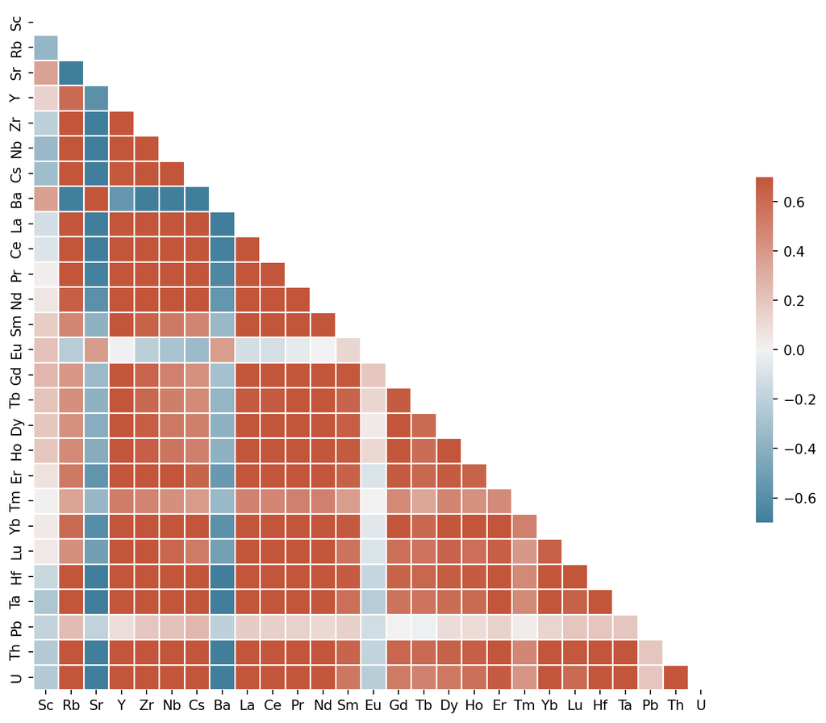

Figure 1: Correlation matrix for the trace elements dataset.

```python
# Keep only the numerical columns, i.e., from column index 10 to the last
df_traces_sub = df_traces.iloc[:, 10:]
corrMatrix(df_traces_sub)
```

**Questions**

Two variables show relatively strong **negative correlations**. These are:

Three variables show relatively **weak correlations**:

## A first look at linear regression

Correlation coefficients provide a measure of the coupling between two continuous variables, and linear regressions attempt modelling this relationship. A linear regression is typically expressed as (Equation 3):

$$y = a + bx + \varepsilon
\tag{3}$$

where:

- $y$: dependent (response) variable
- $x$: independent (predictor) variable
- $a$: intercept → value of $y$ when $x=0$
- $b$: slope → how much $y$ changes by unit of $x$
- $\varepsilon$: error term

So, the goal of a regression for two continuous variables behaving in a linear fashion is to estimate the values of $a$ and $b$ that best fit the observed data.

*Seaborn* has some high-level functions to **plot** linear regressions. These functions are designed to provide a quick overview of the model fit rather than a deep statistical investigation (which is commonly achieved using another library called [statsmodels](https://www.statsmodels.org/stable/index.html)). A thorough introduction to linear regression will be the topic of class 4, so for now let’s just focus on the use of the *Seaborn* functions.

The first function is [`sns.regplot()`](https://seaborn.pydata.org/generated/seaborn.regplot.html#seaborn.regplot), which produces:

1. A scatter plot;
2. A linear regression model fit;
3. A confidence interval (by default 95% in *Seaborn* obtained through *bootstrapping*. The idea behind bootstrapping is to i) randomly removing a proportion of original observations from the dataset, ii) refit the model and compare it to the original fit and iii) repeat this a large number of times - typically thousands of times. For a very good fit, removing observations won’t affect greatly the relationship, and the fit with the subset of points will be near to equal the fit with the complete dataset.

Figure 2 shows two regression plots with the 95% confidence interval. They sure do look pretty, and `sns.regplot()` is a great and efficient way to have a first impression at what a first order polynomial fit would look like, but be careful to not over-interpret them. If you want to further explore and constrain linear fits, do turn to [statsmodels](https://www.statsmodels.org/stable/index.html).

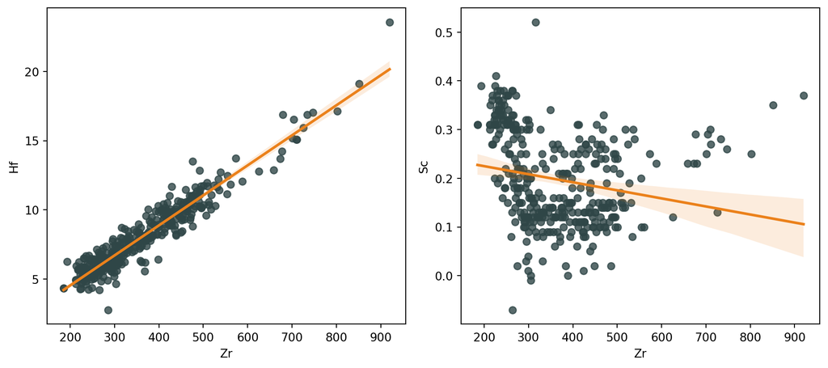

Figure 2: Regression plots obtained using Seaborn.

```python
# Set colors for plotting
blue = '#2F4647'
orange = '#EB811B'

# Setup the plot. Note that we require 2 axes in 1 row, which returns a list of axes (i.e., [ax1, ax2])
fig, [ax1, ax2] = plt.subplots(1,2, figsize=(10,4.5))
sns.regplot(ax=ax1, data=df_traces, x='Zr', y='Hf', color=blue, line_kws=dict(color=orange))
sns.regplot(ax=ax2, data=df_traces, x='Zr', y='Sc', color=blue, line_kws=dict(color=orange))

# These two commands mainly make the plots look good on the website
plt.tight_layout()
plt.show()
```

### Residual analysis

An important - but often overlooked - step to estimating a linear regression model is to investigate whether the residuals show any structure. The residual at each data point $i$ is computed as (Equation 4):

$$\hat{\varepsilon}_i = y_i - \hat{y}_i
\tag{4}$$

where:

- $y_i$ is the measured value along the *y* axis;
- $\hat{y}_i$ is the modelled value along the *y* axis defined as $\hat{y}_i = \hat{a} + \hat{b} x_i$, where $\hat{a}$ and $\hat{b}$ are the estimated intercept and slope of the linear regression;
- $\hat{\varepsilon}_i$ is the residual (error term).

Residuals - beyond being used to compute the $R^2$ coefficient of determination (Equation 5), are critical to:

1. **Diagnose model fit** (→ how much **unexplained variation** remains);
2. **Detect patterns** that indicate problems (non-linearity, heteroscedasticity, outliers).

$$R^2 = 1 - \frac{\sum_{i=1}^{n} (y_i - \hat{y}_i)^2}{\sum_{i=1}^{n} (y_i - \bar{y})^2}
\tag{5}$$

Any type of structure in residuals might reveal a violation of linear regression assumptions. *Seaborn*’s function [`sns.residplot()`](https://seaborn.pydata.org/generated/seaborn.residplot.html) is designed to help with rapid investigation of the potential structure in residuals. Figure 3 shows the residuals for the same relationships as Figure 2. We add the argument `lowess=True` to the function, which uses a [lowess filter](https://en.wikipedia.org/wiki/Local_regression) (i.e., think a combination of a moving average except a linear regression is performed rather than an average). This is useful to estimate the structure of the residuals.

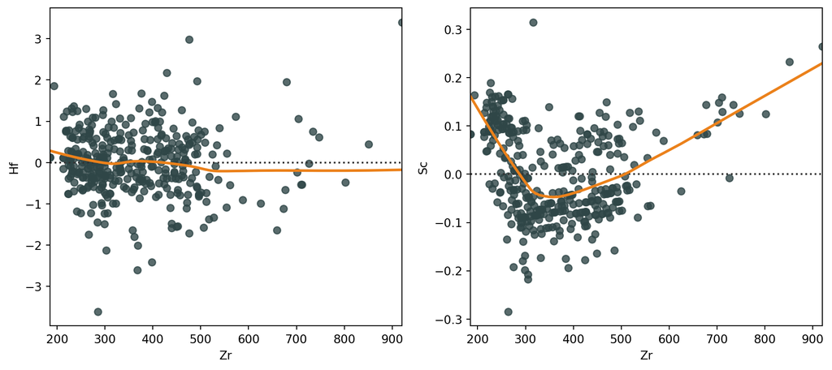

Figure 3: Residual plots obtained using Seaborn.

```python
fig, [ax1, ax2] = plt.subplots(1,2, figsize=(10,4.5))
sns.residplot(ax=ax1, data=df_traces, x='Zr', y='Hf', color=blue, lowess=True, line_kws=dict(color=orange))
sns.residplot(ax=ax2, data=df_traces, x='Zr', y='Sc', color=blue, lowess=True, line_kws=dict(color=orange))
plt.tight_layout()
plt.show()
```

**Estimating regression fits with Seaborn**

*Seaborn* has a [great tutorial](https://seaborn.pydata.org/tutorial/regression.html) on estimating regression fits - be sure to check it out at some point!